# Assignment: Variable Relations

Jon Doretti

2024-06-01 14:16:57

# Instructions

This assignment reviews the *Variable Relations* content. You will use the **variable_relations.Rmd** file I reviewed as part of the lectures for this week to complete this assignment. You will *copy and paste* relevant code from that file and update it to answer the questions in this assignment. You will respond to questions in each section after executing relevant code to answer a question. You will submit this assignment to its *Submissions* folder on *D2L*. You will submit *two* files:

1. this completed *R Markdown* script, and
2. an *HTML* rendered version of it to *D2L*.

To start:

First, create a folder on your computer to save all relevant files for this course. If you did not do so already, you will want to create a folder named **mgt_585** that contains all of the materials for this course.

Second, inside of **mgt_585**, you will create a folder to host assignments. You can name that folder **assignments**. Inside the **assignments** folder, you can create a folder for topic assignments named: **topics**.

Third, inside of the **topics** folder, you will create folders for each assignment. You can name the folder for this assignment: **02_variable_relations**.

Fourth, create two additional folders in **02_variable_relations** named **scripts**, **data**, and **plots**. Store this script in the **scripts** folder and the data for this assignment in the **data** folder.

Fifth, go to the *File* menu in *RStudio*, select *New Project…*, choose *Existing Directory*, go to your */mgt_585/assignments/topics/02_variable_relations* folder to select it as the top-level directory for this *R Project*.

# Global Settings

The first code chunk sets the global settings for the remaining code chunks in the document. Do *not* change anything in this code chunk.

# Activate Packages

In this code chunk, we load the following packages:

1. [here](https://here.r-lib.org);
2. [tidyverse](https://www.tidyverse.org);
3. [lubridate](https://lubridate.tidyverse.org/index.html);
4. [skimr](https://docs.ropensci.org/skimr/);
5. [scales](https://scales.r-lib.org).
6. [snakecase](https://tazinho.github.io/snakecase/);
7. [janitor](https://sfirke.github.io/janitor/);
8. [infer](https://infer.netlify.app/index.html);
9. [corrr](https://corrr.tidymodels.org);
10. [rstatix](https://rpkgs.datanovia.com/rstatix/);
11. [effectsize](https://easystats.github.io/effectsize/).

Make sure you installed these packages when you reviewed the analytical lecture.

We will use functions from these packages to examine the data. Do *not* change anything in this code chunk.

```r
## here for project workflow
library(here)

## tidyverse for data manipulation and plotting;
## loads eight different libraries simultaneously
library(tidyverse)

## lubridate to work with dates
library(lubridate)

## skimr to summarize data
library(skimr)

## scales for variable scales
library(scales)

## snakecase for naming conventions
library(snakecase)

## janitor to clean data and chi-square test
library(janitor)

## infer for inferential frequentist statistics
library(infer)

## corrr for correlations
library(corrr)

## rstatix to compute statistical tests
## and effect sizes
library(rstatix)

## effectsize to compute effect sizes
library(effectsize)
```

# Task 1: Import Data

We will use the same data as in the analytical lecture: **auto_insurance.rds**. After you load the data, then you will execute other commands on the data.

## Task 1.1

Use the **readRDS()** and **here()** functions to load the data file for this working session. Save the data as the object **auto_raw**.

Examine **auto_raw** with **glimpse()**.

**Question 1.1**: Answer these questions: (1) How many *observations* are there in the *raw* data? (2) How many *variables* are there in the *raw* data?

**Response 1.1**: (1) 9134 (2) 24

```r
# Task 1.1: Import Data
# Use readRDS() and here() functions to load the data file
auto_raw <- readRDS(here("data", "auto_insurance.rds"))

# Examine auto_raw with glimpse()
glimpse(auto_raw)
```

```
## Rows: 9,134
## Columns: 24
## $ Customer                        <chr> "BU79786", "QZ44356", "AI49188", "WW63…
## $ State                           <chr> "Washington", "Arizona", "Nevada", "Ca…
## $ `Customer Lifetime Value`       <dbl> 2763.519, 6979.536, 12887.432, 7645.86…
## $ Response                        <chr> "No", "No", "No", "No", "No", "Yes", "…
## $ Coverage                        <chr> "Basic", "Extended", "Premium", "Basic…
## $ Education                       <chr> "Bachelor", "Bachelor", "Bachelor", "B…
## $ `Effective To Date`             <chr> "2/24/11", "1/31/11", "2/19/11", "1/20…
## $ EmploymentStatus                <chr> "Employed", "Unemployed", "Employed", …
## $ Gender                          <chr> "F", "F", "F", "M", "M", "F", "F", "M"…
## $ Income                          <dbl> 56274, 0, 48767, 0, 43836, 62902, 5535…
## $ `Location Code`                 <chr> "Suburban", "Suburban", "Suburban", "S…
## $ `Marital Status`                <chr> "Married", "Single", "Married", "Marri…
## $ `Monthly Premium Auto`          <dbl> 69, 94, 108, 106, 73, 69, 67, 101, 71,…
## $ `Months Since Last Claim`       <dbl> 32, 13, 18, 18, 12, 14, 0, 0, 13, 17, …
## $ `Months Since Policy Inception` <dbl> 5, 42, 38, 65, 44, 94, 13, 68, 3, 7, 5…
## $ `Number of Open Complaints`     <dbl> 0, 0, 0, 0, 0, 0, 0, 0, 0, 0, 0, 0, 2,…
## $ `Number of Policies`            <dbl> 1, 8, 2, 7, 1, 2, 9, 4, 2, 8, 3, 3, 3,…
## $ `Policy Type`                   <chr> "Corporate Auto", "Personal Auto", "Pe…
## $ Policy                          <chr> "Corporate L3", "Personal L3", "Person…
## $ `Renew Offer Type`              <chr> "Offer1", "Offer3", "Offer1", "Offer1"…
## $ `Sales Channel`                 <chr> "Agent", "Agent", "Agent", "Call Cente…
## $ `Total Claim Amount`            <dbl> 384.81115, 1131.46493, 566.47225, 529.…
## $ `Vehicle Class`                 <chr> "Two-Door Car", "Four-Door Car", "Two-…
## $ `Vehicle Size`                  <chr> "Medsize", "Medsize", "Medsize", "Meds…
```

# Task 2: Clean Data

In this task, you will clean the data.

## Task 2.1

In one chained command, perform the following operations:

1. change variable names to snake case using **rename_with()** and **to_snake_case()**;
2. filter the **state** column for **“California”**;
3. convert **c(state, response:education, employment_status:gender, location_code:marital_status, policy_type:sales_channel, vehicle_class:vehicle_size)** to factor variables;
4. update **effective_to_date** to a date variable with **mdy()**;
5. compute **employed_binary** from **employment_status** using **fct_collapse()** to convert **c(“Disabled”, “Unemployed”, “Medical Leave”, “Retired”)** to an **Other** category;
6. relabel the levels of **gender** to **“Male”** and **“Female”**;
7. reorder the levels of **marital_status** to **“Single”, “Married”, “Divorced”**;
8. reorder the levels of **education** to move **“High School or Below”** and **“College”** to the *first* and *second* position, respectively;
9. reorder the levels of **coverage** to move **“Extended”** to the *second* position.

Examine **auto_work** with **glimpse()**.

**Question 2.1**: Answer these questions: (1) How many *observations* are there in the *working* data? (2) How many *factor* variables are there in the *working* data?

**Response 2.1**: (1) 3150 (2) 15

```r
# Assuming auto_raw is the loaded dataset from Task 1.1

auto_work <- auto_raw %>%
  rename_with(.fn =  to_snake_case) %>%
  filter(state == "California") %>%
  mutate(across(.cols = c(state, response:education, employment_status:gender, location_code:marital_status, policy_type:sales_channel, vehicle_class:vehicle_size), .fns = as_factor),
  effective_to_date = mdy(effective_to_date),
  employed_binary = fct_collapse(employment_status, Other = c("Disabled", "Unemployed", "Medical Leave", "Retired")),
  gender = fct_recode(gender, "Male" = "M", "Female" = "F"),
  marital_status = fct_relevel(marital_status, "Single", "Married", "Divorced"),
  education = fct_relevel(education, "High School or Below", "College"),
  coverage = fct_relevel(coverage, "Basic", "Extended", "Premium"))

# Examine auto_work with glimpse()
glimpse(auto_work)
```

```
## Rows: 3,150
## Columns: 25
## $ customer                      <chr> "WW63253", "SX51350", "VQ65197", "DP3936…
## $ state                         <fct> California, California, California, Cali…
## $ customer_lifetime_value       <dbl> 7645.862, 4738.992, 8197.197, 8798.797, …
## $ response                      <fct> No, No, No, No, No, No, No, No, No, No, …
## $ coverage                      <fct> Basic, Basic, Basic, Premium, Basic, Bas…
## $ education                     <fct> Bachelor, College, College, Master, Coll…
## $ effective_to_date             <date> 2011-01-20, 2011-02-21, 2011-06-01, 201…
## $ employment_status             <fct> Unemployed, Unemployed, Unemployed, Empl…
## $ gender                        <fct> Male, Male, Female, Male, Male, Male, Fe…
## $ income                        <dbl> 0, 0, 0, 77026, 83689, 28855, 66140, 178…
## $ location_code                 <fct> Suburban, Suburban, Suburban, Urban, Urb…
## $ marital_status                <fct> Married, Single, Married, Married, Singl…
## $ monthly_premium_auto          <dbl> 106, 67, 110, 110, 70, 101, 101, 61, 111…
## $ months_since_last_claim       <dbl> 18, 23, 27, 9, 21, 12, 11, 30, 15, 19, 1…
## $ months_since_policy_inception <dbl> 65, 5, 87, 82, 10, 59, 21, 91, 47, 56, 6…
## $ number_of_open_complaints     <dbl> 0, 0, 0, 2, 2, 0, 0, 0, 0, 0, 0, 0, 0, 0…
## $ number_of_policies            <dbl> 7, 3, 3, 3, 8, 1, 3, 1, 1, 3, 2, 1, 1, 2…
## $ policy_type                   <fct> Corporate Auto, Personal Auto, Personal …
## $ policy                        <fct> Corporate L2, Personal L3, Personal L3, …
## $ renew_offer_type              <fct> Offer1, Offer1, Offer2, Offer2, Offer4, …
## $ sales_channel                 <fct> Call Center, Agent, Agent, Agent, Call C…
## $ total_claim_amount            <dbl> 529.88134, 482.40000, 528.00000, 472.029…
## $ vehicle_class                 <fct> SUV, Four-Door Car, SUV, Four-Door Car, …
## $ vehicle_size                  <fct> Medsize, Small, Medsize, Medsize, Medsiz…
## $ employed_binary               <fct> Other, Other, Other, Employed, Employed,…
```

# Task 3: Chi-Square Test of Independence

For this task, you will perform a *chi-square test of independence*.

## Task 3.1

Perform two tasks.

First, create a contingency table counting the combinations of **education** and **coverage** from **auto_work** using **tabyl()**. Bind the name **contingent_table** to the object. Print **contingent_table** to view the result.

Second, compute a *chi-square test of independence* using **rstatix::chisq_test()**. Call **contingent_table** and convert the **“education”** column to *row names* with **column_to_rownames()**. Bind the name **chisq_indep_test** to the object. Print **chisq_indep_test** to view the result.

**Question 3.1**: Answer these questions: (1) Irrespective of *educational degree*, what coverage to customers buy the most often? (2) What is the *empirical chi-square* value?

**Response 3.1**: (1) Basic (2) 12.1

```r
### create a table for two factors
## save as tibble
contingent_table <- tabyl(
  ## data
  auto_work,
  ## factor variables
  education, coverage
)

## print
contingent_table
```

| education | Basic | Extended | Premium |
| --- | --- | --- | --- |
| High School or Below | 526 | 262 | 89 |
| College | 559 | 308 | 81 |
| Bachelor | 613 | 273 | 85 |
| Master | 158 | 72 | 24 |
| Doctor | 60 | 37 | 3 |

```r
chisq_indep_test <- rstatix::chisq_test(
  ## data
  contingent_table %>%
    ## make column row names
    column_to_rownames(
      # row names
      var = "education"
    )
)


## print result
chisq_indep_test
```

|  | n | statistic | p | df | method | p.signif |
| --- | --- | --- | --- | --- | --- | --- |
| 1 | 3150 | 12.11854 | 0.146 | 8 | Chi-square test | ns |

## Task 3.2

Perform two tasks.

First, calculate the *observed chi-square statistic* using the **infer** functions and bind the name, **chisq_indep_stat**, to it. Call **auto_work** and pipe it to **specify()** and set the *formula* input to **marital_status ~ vehicle_class**. Pipe the result to **hypothesize()** and set **null** to **“independence”**. Pipe the result to **calculate()** and set **stat** to **“Chisq”**. Print **chisq_indep_stat** to view the result.

Second, produce a visualization using the **infer** functions. Call **auto_work** and pipe it to **specify()** and set the *formula* input to **marital_status ~ vehicle_class**. Pipe the result to **assume()** and set **distribution** to **“Chisq”**. Pipe the result to **visualize()**. Pipe the result to **shade_p_value()** and set **chisq_indep_stat** as the observed result and **direction** to **“greater”**. Pipe the result to **labs()** and set approporiate axes labels.

**Question 3.2**: Are there shaded *theoretical* chi-square values to the right of the *observed* chi-square values?

**Response 3.2**: Yes

```r
# Calculate the observed chi-square statistic
chisq_indep_stat <- auto_work %>%
  specify(formula = marital_status ~ vehicle_class) %>%
  hypothesize(null = "independence") %>%
  calculate(stat = "Chisq")

# Print the result
chisq_indep_stat
```

| stat |
| --- |
| 10.03638 |

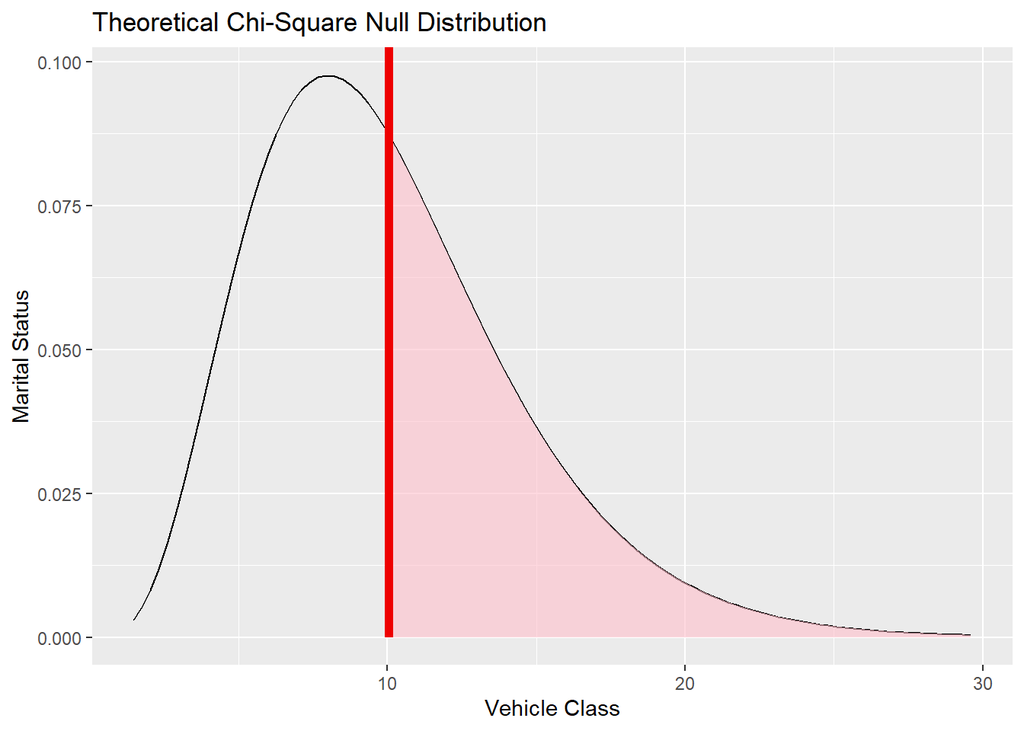

```r
# Produce a visualization
auto_work %>%
  specify(formula = marital_status ~ vehicle_class) %>%
  assume(distribution = "Chisq") %>%
  visualize() +
  shade_p_value(
    chisq_indep_stat,
    direction = "greater"
  ) +
  labs(
    x = "Vehicle Class",
    y = "Marital Status"
  )
```

## Task 3.3

Perform three tasks.

First, calculate the effect size in this case using **cramers_v()**. Call **contingent_table** and convert the **“education”** column to *row names* with **column_to_rownames()**. Set the **ajust** input to **FALSE**. Pipe the result to **as_tibble()**.

Second, bind the name, **obs_exp_freq**, to the following object. Call **chisq_descriptives()** with **chisq_indep_test** as the input. Pipe the result to **rename()** and rename **Var1** to **education** and **Var2** to **coverage**. Pipe the result to **select()** and select **coverage, education, observed, expected**. Pipe the result to **pivot_longer()** and set **cols** to **c(observed, expected)**, **names_to** to **“count_type”**, and **values_to** to **“count”**. Pipe the result to **mutate()**: first apply **str_to_title** and second apply **as_factor()** to **count_type** to update the column. Pipe the result to **group_by()** to form groups as a function of **education** and **count_type**. Pipe the result to **mutate()** to compute **coverage_prop** as a function of **count / sum(count)**. Pipe the result to **ungroup()**. Print **obs_exp_freq** to view the result.

Third, bind the name, **obs_exp_freq_plot**, to the following object. Call **ggplot()** and set **obs_exp_freq** as the *data* input and map **coverage_prop**, **education**, and **fct_rev(coverage)** to the **x**, **y**, and **fill** aesthetics, respectively. Add a **facet_grid()** layer and set **cols** to **vars(count_type)**. Add a **geom_col()** layer. Add a **geom_text()** layer and set **label** to *percentage* **coverage_prop** with *one decimal place*, **position** to **position_fill()** with **vjust = 0.5**, **size** to **3**, **fontface** to **bold**, and **color** to **black** (not **white** like the lecture script). Update the *fill* aesthetic with **scale_fill_brewer()** to set **palette** to **“Set1”**. Update the *legend* with **guides()** to set **fill** to *reverse* the legend labels using **guide_legend()**. Update the *x-axis labels* with **scale_x_continuous()** and **percent_format()**. Use **labs()** to update the *x-axis* title to **“Frequency Percentage of Coverage”**, *y-axis* title to **“Education”**, and *fill* title to **“Coverage”**. Use **theme()** to move the *legend* to the *bottom*, change the *panel background* to **“whitesmoke”**, *remove* the *panel grid lines*, and change the *plot background* to **“mintcream”**. Print **obs_exp_freq_plot** to view the plot.

**Question 3.3**: Answer these questions: (1) What is the estimate of *Cramer’s V* in this case? (2) For the most part, do the *observed* and *expected* frequencies match closely?

**Response 3.3**: (1) 0.0439 (2) Yes, the largest variance is Doctor and that is around 7-8%.

```r
effect_size <- contingent_table %>%
  column_to_rownames(var = "education") %>%
  cramers_v(adjust = FALSE) %>%
  as_tibble()

# Print the effect size
print(effect_size)
```

```
## # A tibble: 1 × 4
##   Cramers_v    CI CI_low CI_high
##       <dbl> <dbl>  <dbl>   <dbl>
## 1    0.0439  0.95      0       1
```

```r
obs_exp_freq <- chisq_descriptives(
  chisq_indep_test
) %>%
  rename(education = Var1, coverage = Var2) %>%
  select(coverage, education, observed, expected) %>%
  pivot_longer(cols = c(observed, expected), names_to = "count_type", values_to = "count") %>%
  mutate(count_type = str_to_title(count_type), as_factor(count_type)) %>%
  group_by(education, count_type) %>%
  mutate(coverage_prop = count / sum(count)) %>%
  ungroup()

## print
obs_exp_freq
```

| coverage | education | count_type | count | as_factor(count_type) | coverage_prop |
| --- | --- | --- | --- | --- | --- |
| Basic | High School or Below | Observed | 526.000000 | Observed | 0.59977195 |
| Basic | High School or Below | Expected | 533.438730 | Expected | 0.60825397 |
| Basic | College | Observed | 559.000000 | Observed | 0.58966245 |
| Basic | College | Expected | 576.624762 | Expected | 0.60825397 |
| Basic | Bachelor | Observed | 613.000000 | Observed | 0.63130793 |
| Basic | Bachelor | Expected | 590.614603 | Expected | 0.60825397 |
| Basic | Master | Observed | 158.000000 | Observed | 0.62204724 |
| Basic | Master | Expected | 154.496508 | Expected | 0.60825397 |
| Basic | Doctor | Observed | 60.000000 | Observed | 0.60000000 |
| Basic | Doctor | Expected | 60.825397 | Expected | 0.60825397 |

[output cut: 20 more lines]

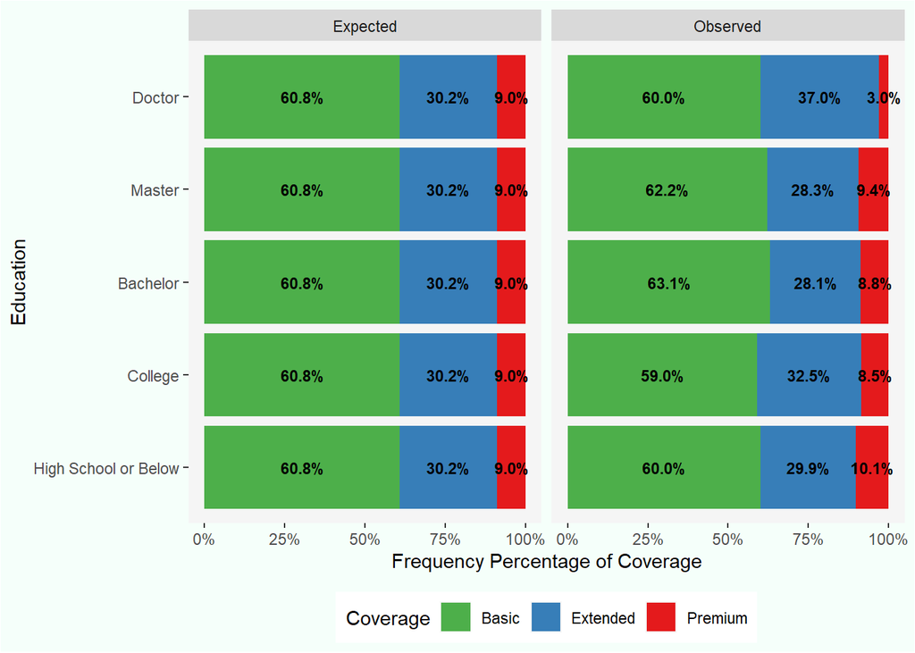

```r
obs_exp_freq_plot <- ggplot(obs_exp_freq, aes(x = coverage_prop, y = education, fill = fct_rev(coverage))) +
  ## facets
  facet_grid(cols = vars(count_type)) +
  geom_col() +
  geom_text(aes(label = percent(coverage_prop, accuracy = 0.1)),
            position = position_fill(vjust = 0.5), size = 3, fontface = "bold", color = "black") +
  scale_fill_brewer(palette = "Set1") +
  guides(fill = guide_legend(reverse = TRUE)) +
  scale_x_continuous(labels = percent_format()) +
  labs(x = "Frequency Percentage of Coverage", y = "Education", fill = "Coverage") +
  theme(legend.position = "bottom",
        panel.background = element_rect(fill = "whitesmoke"),
        panel.grid.major = element_blank(),
        panel.grid.minor = element_blank(),
        plot.background = element_rect(fill = "mintcream"))

## show plot
obs_exp_freq_plot
```

# Task 4: Independent Samples t-test

For this task, you will perform an *independent samples t-test*.

## Task 4.1

Perform two tasks.

First, calculate the average *total claim amounts* by *gender*. Call **auto_work** and *select* **gender** and **total_claim_amount**. Pipe the result to **group_by()** to form groups by **gender**. Pipe the result to **skim()**. Pipe the result to **yank()** to extract the *numeric* summary.

Second, compute an *independent samples t-test* using **infer::t_test()**. Specify **auto_work** as the *data* input, **total_claim_amount ~ gender** as the *formula* input, **c(“Male”, “Female”)** as the *order* input, and **0.95** as the *confidence interval* input. Bind the name **t_test_res** to the object. Print **t_test_res** to view the result.

**Question 4.1**: Answer these questions: (1) What is the average total claim amount for *men*? (2) What is the *empirical t-value*?

**Response 4.1**: (1) 458 (2) 3.76

```r
auto_work %>%
  select(gender, total_claim_amount) %>%
  group_by(gender) %>%
  skim() %>%
  yank("numeric")
```

**Variable type: numeric**

| skim_variable | gender | n_missing | complete_rate | mean | sd | p0 | p25 | p50 | p75 | p100 | hist |
| --- | --- | --- | --- | --- | --- | --- | --- | --- | --- | --- | --- |
| total_claim_amount | Male | 0 | 1 | 457.59 | 306.04 | 0.89 | 292.80 | 398.40 | 564.01 | 2275.27 | ▇▅▁▁▁ |
| total_claim_amount | Female | 0 | 1 | 418.23 | 280.62 | 0.42 | 254.41 | 369.71 | 537.60 | 2452.89 | ▇▃▁▁▁ |

```r
t_test_res <- infer::t_test(
  auto_work, total_claim_amount ~ gender, order = c("Male", "Female"), conf_level = 0.95)

t_test_res
```

| statistic | t_df | p_value | alternative | estimate | lower_ci | upper_ci |
| --- | --- | --- | --- | --- | --- | --- |
| 3.761325 | 3119.628 | 0.0001721204 | two.sided | 39.36079 | 18.84258 | 59.87901 |

## Task 4.2

Perform two tasks.

First, calculate the *observed mean difference* using the **infer** functions and bind the name, **mean_diff**, to it. Call **auto_work** and pipe it to **specify()** and set the *formula* input to **total_calim_amount ~ gender**. Pipe the result to **calculate()** and set **stat** to **“diff in means”** and **order** to **c(“Male”, “Female”)**. Print **mean_diff** to view the result.

## Task 4.3

Perform two tasks.

First, calculate the effect size in this case using **cohens_d()**. Specify **total_claim_amount ~ gender** as the *formula* input and **auto_work** as the *data* input. Set the **pooled_sd** input to **FALSE**. Pipe the result to **as_tibble()**.

Second, bind the name, **mean_diff_plot**, to the following object. Call **ggplot()** and set **auto_work** as the *data* input and map **gender** and **total_claim_amount** to the **x** and **y** aesthetics, respectively. Add a **geom_bar()** layer setting **fill** to **gender**, **stat** to **“summary”**, and **fun** to **“mean”**. Add a **geom_errorbar()** layer setting **stat** to **“summary”**, **fun.data** to **“mean_se”**, **fun.args** to **list(mult = 1.96)**, **size** to **1.5**, and **width** to **0.25**. Add a **geom_text()** layer and set **label** to **after_stat(y)** with *one decimal place*, **stat** to **“summary”**, and **fun** to **“mean”**, **vjust** to **3**, **size** to **6**, **fontface** to **bold**, and **color** to **white**. Use **labs()** to update the *x-axis* title to **NULL** and *y-axis* title to **“Average Total Claim Amount”**. Update the *fill* aesthetic with **scale_fill_brewer()** to set **palette** to **“Set1”**. Use **theme()** to *remove* the *legend*, change the *panel background* to **“whitesmoke”**, *remove* the *panel grid lines*, and change the *plot background* to **“mintcream”**. Print **mean_diff_plot** to view the plot.

**Question 4.3**: Answer these questions: (1) What is the estimate of *Cohen’s d* in this case? (2) Do *men* or *women* have higher *average total claim amounts*?

**Response 4.3**: (1) .134 (2) Men at $457.6.

```r
cohens_d(
  ## formula
  total_claim_amount ~ gender,
  ## data
  data = auto_work,
  ## pooled sd
  pooled_sd = FALSE
) %>%
  ## convert to tibble
  as_tibble()
```

| Cohens_d | CI | CI_low | CI_high |
| --- | --- | --- | --- |
| 0.1340613 | 0.95 | 0.0641143 | 0.2039868 |

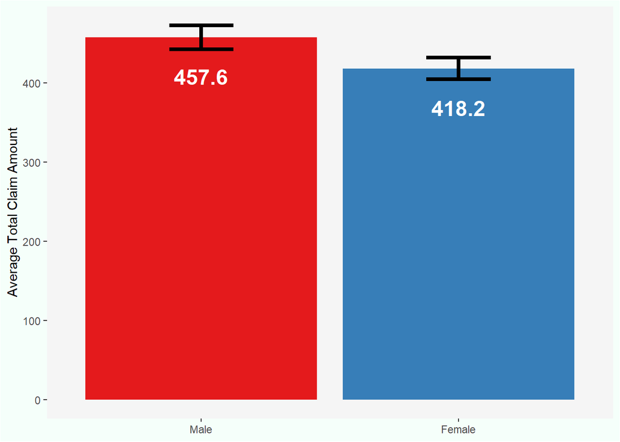

```r
mean_diff_plot <- ggplot(auto_work, aes(x = gender, y = total_claim_amount)) +
  geom_bar(aes( fill = gender), stat = "summary", fun = "mean") +
  geom_errorbar(
    stat = "summary", fun.data = "mean_se", fun.args = list(mult = 1.96),
    size = 1.5, width = 0.25
  ) +
  geom_text(
    aes(label = number(after_stat(y), accuracy = 0.1)),
    stat = "summary", fun = "mean", vjust = 3, size = 6, fontface = "bold", color = "white"
  ) +
  labs(x = NULL, y = "Average Total Claim Amount") +
  scale_fill_brewer(palette = "Set1") +
  theme(
    legend.position = "none",
    panel.background = element_rect(fill = "whitesmoke"),
    plot.background = element_rect(fill = "mintcream"),
    panel.grid = element_blank()
  )

mean_diff_plot
```

# Task 5: Pearson’s Correlation Coefficient

For this task, you will perform a *correlation test*.

## Task 5.1

Perform two tasks.

First, calculate the correlation between **income** and **total_claim_amount**. Call **auto_work** and *select* **income** and **total_claim_amount**. Pipe the result to **correlate()**.

Second, compute a *correlation test* using **cor_test()**. Specify **auto_work** as the *data* input and **income** and **total_claim_amount** as the continuous variables. Bind the name **cor_test_res** to the object. Print **cor_test_res** to view the result.

**Question 5.1**: Answer these questions: (1) What is the correlation value? (2) What is the *empirical t-value*?

**Response 5.1**: (1) -0.375 (2) -22.735

```r
auto_work %>%
  select(income, total_claim_amount) %>%
  correlate()
```

| term | income | total_claim_amount |
| --- | --- | --- |
| income | NA | -0.3755468 |
| total_claim_amount | -0.3755468 | NA |

```r
corr_test_res <- cor.test(
  auto_work$income, auto_work$total_claim_amount)

## print result
corr_test_res
```

```
##
##  Pearson's product-moment correlation
##
## data:  auto_work$income and auto_work$total_claim_amount
## t = -22.735, df = 3148, p-value < 2.2e-16
## alternative hypothesis: true correlation is not equal to 0
## 95 percent confidence interval:
##  -0.4051569 -0.3451497
## sample estimates:
##        cor
## -0.3755468
```

## Task 5.2

Perform two tasks.

First, calculate the *observed correlation* using the **infer** functions and bind the name, **corr_res**, to it. Call **auto_work** and pipe it to **specify()** and set the *formula* input to **total_claim_amount ~ income**. Pipe the result to **calculate()** and set **stat** to **“correlation”**. Print **corr_res** to view the result.

Second, produce a visualization using the **infer** functions. Call **auto_work** and pipe it to **specify()** and set the *formula* input to **total_calim_amount ~ income**. Pipe the result to **hypothesize()** and set **null** to **“independence”**. Pipe the result to **generate()** and set **reps** to **1000** and **type** to **“permute”**. Pipe the result to **calculate()** and set **stat** to **“correlation”**. Pipe the result to **visualize()**. Pipe the result to **shade_p_value()** and set **corr_res** as the observed result and **direction** to **“two-sided”**. Pipe the result to **labs()** and set appropriate axes labels.

**Question 5.2**: Are there shaded *theoretical* correlation values to the *left* of the *observed* correlation value?

**Response 5.2**: No

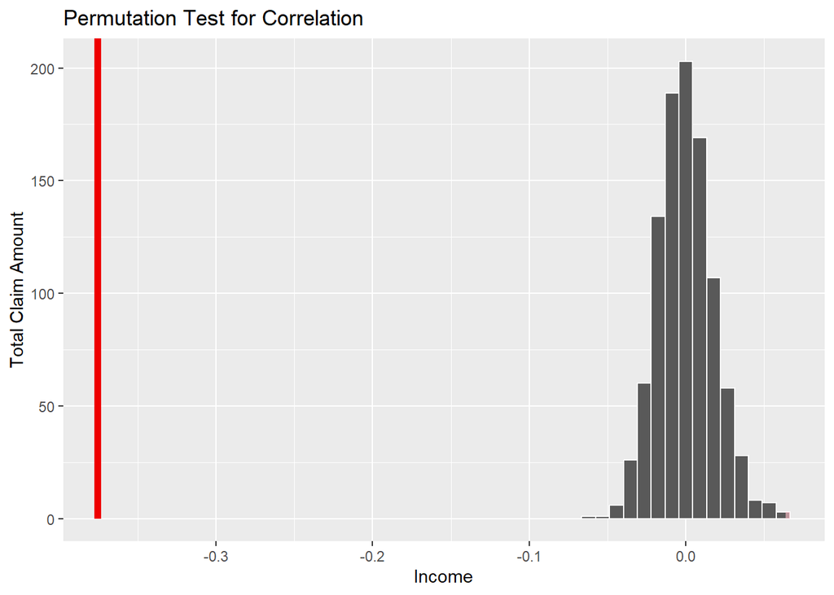

```r
# Calculate observed correlation
corr_res <- auto_work %>%
  specify(total_claim_amount ~ income) %>%
  calculate(stat = "correlation")


# Visualization
auto_work %>%
  specify(total_claim_amount ~ income) %>%
  hypothesize(null = "independence") %>%
  generate(reps = 1000, type = "permute") %>%
  calculate(stat = "correlation") %>%
  visualize() +
  shade_p_value(corr_res, direction = "two-sided") +
  labs(
    x = "Income",
    y = "Total Claim Amount",
    title = "Permutation Test for Correlation"
  )
```

## Task 5.3

Perform two tasks.

First, calculate the effect size in this case by raising **corr_res** to **2**.

Second, bind the name, **corr_plot**, to the following object. Call **ggplot()** and set **auto_work** as the *data* input and map **income** and **total_claim_amount** to the **x** and **y** aesthetics, respectively. Add a **geom_point()** layer and set **alpha** to **0.3**. Add a **geom_smooth()** layer and set **method** to **“lm”**, **formula** to **“y ~ x”**, and **se** to **FALSE**. Use **labs()** to update the *x-axis* title to **“Income”** and *y-axis* title to **“Total Claim Amount”**. Update the *x-axis labels* with **scale_x_continuous** and **dollar_format()** with **breaks** set to **seq(0, 100000, 25000)**. Update the *y-axis labels* with **scale_y_continuous** and **dollar_format()** with **breaks** set to **seq(0, 2500, 500)**. Use **theme()** to change the *panel background* to **“whitesmoke”** and the *plot background* to **“mintcream”**. Print **corr_plot** to view the plot.

**Question 5.3**: Answer these questions: (1) What is the estimate of *r-squared* in this case? (2) Do *income* and *total claim amount* exhibit a *positive* or *negative* linear relationship?

**Response 5.3**: (1) 0.1410354 (2) They exhibit a negative linear realtionship.

```r
# Print the result
corr_res^2
```

| stat |
| --- |
| 0.1410354 |

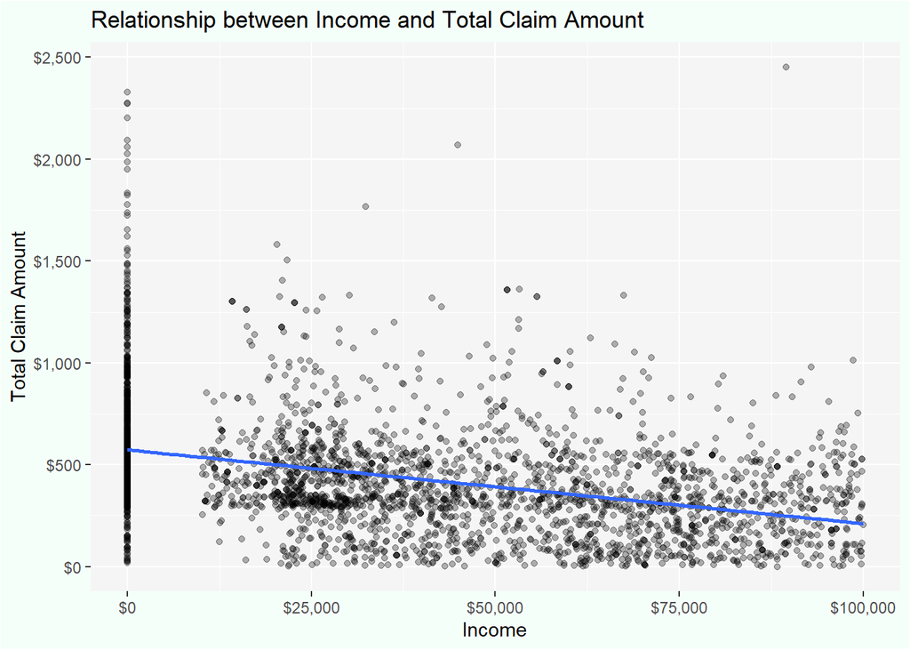

```r
corr_plot <- ggplot(auto_work, aes(x = income, y = total_claim_amount)) +
                      geom_point(alpha = 0.3) +
                      geom_smooth(method = "lm", formula = "y ~ x", se = FALSE) +
                      labs(
                            x = "Income",
                            y = "Total Claim Amount",
                            title = "Relationship between Income and Total Claim Amount"
                      ) +
                      scale_x_continuous(
                            labels = dollar_format(),
                            breaks = seq(0, 100000, 25000)
                      ) +
                      scale_y_continuous(
                            labels = dollar_format(),
                            breaks = seq(0, 2500, 500)
                      ) +
                      theme(
                            panel.background = element_rect(fill = "whitesmoke"),
                            plot.background = element_rect(fill = "mintcream")
                      )

## show plot
corr_plot
```

# Task 6: Save Objects

For this task, you will save the objects you created.

First, save the working data, **auto_work**, as the data file: **auto_work_california.rds** in the **data** folder of the project directory using **saveRDS()** and **here()**.

Second, save the three plot objects as **png** files in the **plots** folder of the project directory using the combination of **walk()**, **ls()**, **ggsave()**, **here()**, **str_glue()**, **str_remove()**, and **get()**. Use a width of *8.1 inches* and a height of *5 inches*.

```r
### save working data
## use write_tsv() to export as a csv data file
saveRDS(
  ## name of object
  auto_work,
  ## use here() to export data to project directory
  here(
    # folder
    "data",
    # file
    "auto_work_california.rds"
  )
)

### save plots
## call function
walk(
  ## vector of plots
  ls(
    # name pattern
    pattern = "plot"
  ),
  ## function
  function(plot_inp) {
    ### save plot
    ## call function
    ggsave(
      ## file path
      here(
        # folder
        "plots",
        # file
        str_glue(
          # remove string
          str_remove(
            # string
            plot_inp,
            # pattern
            "_plot"
          ),
          # extension
          ".png"
        )
      ),
      ## plot object
      plot = get(plot_inp),
      ## units
      units = "in",
      ## width
      width = 8.1,
      ## height
      height = 5
    )
  }
)
```

# Task 7: Conceptual Questions

For your last task, you will respond to conceptual questions based on the conceptual lectures for this week.

**Question 7.1**: What does a chi-square test of independence evaluate?

**Response 7.1**: A chi-square test of independence evaluates whether there is a statistically significant association between two categorical variables in a contingency table. It tests the null hypothesis that the two variables are independent versus the alternative hypothesis that there is a relationship between them.

**Question 7.2**: What does an independent samples t-test evaluate?

**Response 7.2**: An independent samples t-test evaluates whether the means of two independent groups are significantly different from each other. It tests the null hypothesis that the population means of the two groups are equal versus the alternative hypothesis that they are not equal.

**Question 7.3**: What does a test using Pearson’s correlation coefficient evaluate?

**Response 7.3**: A test using Pearson’s correlation coefficient evaluates the strength and direction of the linear relationship between two continuous variables. It measures the degree to which the two variables are linearly related, with values ranging from -1 (perfect negative correlation) to +1 (perfect positive correlation), and 0 indicating no linear correlation.